# Satellite Images of Hurricane Damage

Zulato Davide - Denova Matteo - Ferro Simone

25/2/2022

## Hurricane Damage

Task di classificazione binaria

## Caricamento Dataset

Il dataset in esame è composto da immagini satellitari successive all’Uragano che ha colpito il Texas nel 2017.Le immagini sono divise in 2 gruppi (damage and no_damage). L’obiettivo è di implementare un modello che sia in grado di identificare automaticamente se una regione ha subito danni legati all’allagamento.

Carichiamo le librerie necessarie e definiamo la directory di lavoro

```r
library(keras)
library(tensorflow)
setwd("C:/Users/Davide Zulato/Desktop/satellite")
getwd()
```

```
## [1] "C:/Users/Davide Zulato/Desktop/satellite"
```

## Directory di lavoro

Nel dataset utilizzato in questo lavoro le immagini sono suddivise in 4 cartelle, ognuna delle quali contiene a sua volta le sottocartelle damage e no_damage: Training (train_another): 10000 immagini (5000 damage e 5000 no_damage) Validation (validation_another): 1000 immagini per ogni classe Test (test_another): test sbilanciato 8000 damaged e 1000 undamaged Test Bilanciato (test): 1000 immagini per ogni classe

Dopo aver scaricato il dataset, con il codice seguente definiamo la directory di lavoro e verifichiamo la dimensione dei rispettivi sets

```r
original_dataset_dir <- "C:/Users/Davide Zulato/Desktop/satellite"
base_dir <- "C:/Users/Davide Zulato/Desktop/satellite"

train_damage_dir <- "C:/Users/Davide Zulato/Desktop/satellite/train_another/damage"
cat("total training damage images:", length(list.files(train_damage_dir)), "\n")
```

```
## total training damage images: 5000
```

```r
train_no.damage_dir <- "C:/Users/Davide Zulato/Desktop/satellite/train_another/no_damage"
cat("total training no damage images:", length(list.files(train_no.damage_dir)), "\n")
```

```
## total training no damage images: 5000
```

```r
validation_damage_dir <- "C:/Users/Davide Zulato/Desktop/satellite/validation_another/damage"
cat("total validation damage images:", length(list.files(validation_damage_dir)), "\n")
```

```
## total validation damage images: 1000
```

```r
validation_no.damage_dir <- "C:/Users/Davide Zulato/Desktop/satellite/validation_another/no_damage"
cat("total validation nodamage images:", length(list.files(validation_no.damage_dir)), "\n")
```

```
## total validation nodamage images: 1000
```

```r
testsbil_damage_dir <- "C:/Users/Davide Zulato/Desktop/satellite/test_another/damage"
cat("total test sbilanciato damage images:", length(list.files(testsbil_damage_dir)), "\n")
```

```
## total test sbilanciato damage images: 8000
```

```r
testsbil_no.damage_dir <- "C:/Users/Davide Zulato/Desktop/satellite/test_another/no_damage"
cat("total test sbilanciato no damage images:", length(list.files(testsbil_no.damage_dir)), "\n")
```

```
## total test sbilanciato no damage images: 1000
```

```r
testbil_damage_dir <- "C:/Users/Davide Zulato/Desktop/satellite/test/damage"
cat("total test bilanciato damage images:", length(list.files(testbil_damage_dir)), "\n")
```

```
## total test bilanciato damage images: 1000
```

```r
testbil_no.damage_dir <- "C:/Users/Davide Zulato/Desktop/satellite/test/no_damage"
cat("total test bilanciato no damage images:", length(list.files(testbil_no.damage_dir)), "\n")
```

```
## total test bilanciato no damage images: 1000
```

## Preparazione dei dati

Le immagini del dataset sono in formato .jpeg, i dati devono quindi essere trasformarti in tensori e utilizzati (tensori 3D) come input nella rete. la preparazione dei dati avviene attraverso i seguenti steps:

1)Leggere i file delle immagini. 2)Trasformare le immagini da JPEG a RGB (griglia di pixels). 3)Convertire il risultato in tensori di tipo floating. 4)Riscale i pixel in un intervallo tra [0, 1].

I passaggi sono svolti attraverso la funzione image_data_generator()

```r
train_datagen <- image_data_generator(rescale = 1/255)
```

```
## Loaded Tensorflow version 2.3.0
```

```r
validation_datagen <- image_data_generator(rescale = 1/255)
test_datagen <- image_data_generator(rescale = 1/255)

train_dir <- "C:/Users/Davide Zulato/Desktop/satellite/train_another"

train_generator <- flow_images_from_directory(
  train_dir,
  train_datagen,
  # Riscaliamo le immagini tra 150 x 150
  target_size = c(150, 150),
  batch_size = 32,
  # classificazione binaria
  class_mode = "binary"
)

validation_dir <- "C:/Users/Davide Zulato/Desktop/satellite/validation_another"

validation_generator <- flow_images_from_directory(
  validation_dir,
  validation_datagen,
  target_size = c(150, 150),
  batch_size = 32,
  class_mode = "binary"
)
```

La dimensionalità dell’output sarà (32,150,150,3). 32 immagini per batch ognuna delle quali ha dimensione 150 x 150 in qualità RGB (3)

## Architettura prima rete

L’architettura della rete segue la classica struttura delle reti convoluzionali: alterniamo convolutional layers a pooling layers (Max pooling). gli ultimi strati seguono una struttura FFNN e sono quelli che operano la classificazione binaria; l’ultimo strato, poichè ci confrontiamo con un task di classificazione binaria, è formato da una funzione di attivazione di tipo sigmoidale. Scegliamo un dropout rate del 50% che si applica all’output del layer immediatamente precedente.

Osserviamo che la profondità delle feature maps aumenta di strato in strato, mentre la dimensione delle feature maps diminuisce.

```r
model <- keras_model_sequential() %>%
  layer_conv_2d(filters = 32, kernel_size = c(3, 3), activation = "relu",
                input_shape = c(150, 150, 3)) %>%
  layer_max_pooling_2d(pool_size = c(2, 2)) %>%
  layer_conv_2d(filters = 64, kernel_size = c(3, 3), activation = "relu") %>% layer_max_pooling_2d(pool_size = c(2, 2)) %>%
  layer_conv_2d(filters = 128, kernel_size = c(3, 3), activation = "relu") %>% layer_max_pooling_2d(pool_size = c(2, 2)) %>%
  layer_conv_2d(filters = 128, kernel_size = c(3, 3), activation = "relu") %>% layer_max_pooling_2d(pool_size = c(2, 2)) %>%
  layer_flatten() %>%
  layer_dropout(rate = 0.5) %>%
  layer_dense(units = 512, activation = "relu") %>%
  layer_dense(units = 1, activation = "sigmoid")

summary(model)
```

```
## Model: "sequential"
## ________________________________________________________________________________
## Layer (type)                        Output Shape                    Param #
## ================================================================================
## conv2d_3 (Conv2D)                   (None, 148, 148, 32)            896
## ________________________________________________________________________________
## max_pooling2d_3 (MaxPooling2D)      (None, 74, 74, 32)              0
## ________________________________________________________________________________
## conv2d_2 (Conv2D)                   (None, 72, 72, 64)              18496
## ________________________________________________________________________________
## max_pooling2d_2 (MaxPooling2D)      (None, 36, 36, 64)              0
## ________________________________________________________________________________
## conv2d_1 (Conv2D)                   (None, 34, 34, 128)             73856
## ________________________________________________________________________________
## max_pooling2d_1 (MaxPooling2D)      (None, 17, 17, 128)             0
## ________________________________________________________________________________
## conv2d (Conv2D)                     (None, 15, 15, 128)             147584
## ________________________________________________________________________________
## max_pooling2d (MaxPooling2D)        (None, 7, 7, 128)               0
## ________________________________________________________________________________
## flatten (Flatten)                   (None, 6272)                    0
## ________________________________________________________________________________
## dropout (Dropout)                   (None, 6272)                    0
## ________________________________________________________________________________
## dense_1 (Dense)                     (None, 512)                     3211776
## ________________________________________________________________________________
## dense (Dense)                       (None, 1)                       513
## ================================================================================
## Total params: 3,453,121
## Trainable params: 3,453,121
## Non-trainable params: 0
## ________________________________________________________________________________
```

## Model Compile

In questo passaggio utilizzeremo l’ottimizzatore RMSprop e la binary crossentropy come loss function poichè ci troviamo in un contesto di classificazione binaria. il learning rate scelto è 1e-4.

```r
model %>% compile(
  loss = "binary_crossentropy",
  optimizer = optimizer_rmsprop(learning_rate = 1e-4),
  metrics = c("acc")
)
```

## Alleniamo il modello

Attraverso i comandi successivi alleniamo il modello specificato in precedenza utilizzando 100 epoche e 100 steps per epoca.salviamo poi il modello dopo il training e osserviamo la performance nel training e nel validation per valutare l’eventuale presenza di overfitting.

```r
history <- model %>% fit(
  train_generator,
  # Numero di campioni per ogni epoch
  steps_per_epoch = 100,
  epochs = 100,
  validation_data = validation_generator,
  # batches da prendere dal validation_generator
  validation_steps = 50
)

# Salviamo il modello .
model %>% save_model_hdf5("Damage_NOdamage_1.h5")
```

Curve di loss e accuracy in training e validation

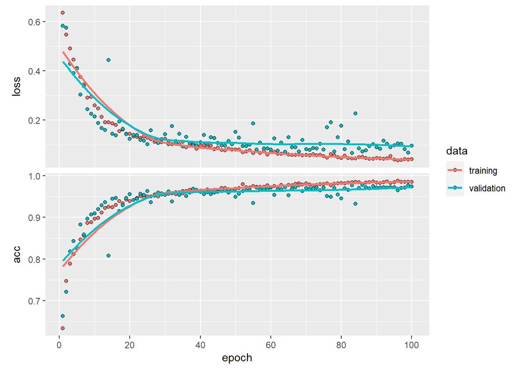

```r
# Confronto tra training e validation
plot(history)
```

Il confronto tra train e validation non mostra preoccupanti caratteristiche di overfitting, l’utilizzo del dropout ha portato a miglioramenti. Il dropout, applicato ad un layer durante il training, inibisce (i.e. setta a zero) un numero casuale di output features dello strato (50% nella nostra rete) al fine di evitare le la rete insista nell’acquisire patterns non rilevanti.

## Performances sui test set bilanciato e sbilanciato

Il dataset contiene sia un test set bilanciato che un test set sbilanciato. il test sbilanciato è composto da 1000 non danneggiati e da 8000 danneggiati. il test bilanciato è invece composto da 2000 immagini equamente divise tra danneggiate e non danneggiate.

```r
test_dir <- "C:/Users/Davide Zulato/Desktop/satellite/test_another"
test.bil_dir <- "C:/Users/Davide Zulato/Desktop/satellite/test"

test_generator <- flow_images_from_directory(
  test_dir,
  test_datagen,
  target_size = c(150, 150),
  batch_size = 32,
  class_mode = "binary"
)

test.bil_generator <- flow_images_from_directory(
  test.bil_dir,
  test_datagen,
  target_size = c(150, 150),
  batch_size = 32,
  class_mode = "binary"
)
```

Valutiamo l’accuracy sul test set sbilanciato

```r
model %>% evaluate_generator(test_generator, steps = 50)
```

```
##      loss       acc
## 0.0679858 0.9825000
```

Valutiamo l’accuracy sul test set Bilanciato

```r
model %>% evaluate_generator(test.bil_generator, steps = 50)
```

```
##       loss        acc
## 0.08498786 0.97687501
```

##Visualizziamo come la nostra rete apprende i patterns dalle immagini

ci occupiamo in particolare di visualizzare gli output intermedi della rete convoluzionale(intermediate activations) informativi per comprendere come la rete trasforma l’input attraverso layers successivi.

```r
library(keras)
# carichiamo il modello salvato, la prima rete mostrata
model <- load_model_hdf5("Damage_NOdamage_1.h5")
model
```

```
## Model
## Model: "sequential"
## ________________________________________________________________________________
## Layer (type)                        Output Shape                    Param #
## ================================================================================
## conv2d_3 (Conv2D)                   (None, 148, 148, 32)            896
## ________________________________________________________________________________
## max_pooling2d_3 (MaxPooling2D)      (None, 74, 74, 32)              0
## ________________________________________________________________________________
## conv2d_2 (Conv2D)                   (None, 72, 72, 64)              18496
## ________________________________________________________________________________
## max_pooling2d_2 (MaxPooling2D)      (None, 36, 36, 64)              0
## ________________________________________________________________________________
## conv2d_1 (Conv2D)                   (None, 34, 34, 128)             73856
## ________________________________________________________________________________
## max_pooling2d_1 (MaxPooling2D)      (None, 17, 17, 128)             0
## ________________________________________________________________________________
## conv2d (Conv2D)                     (None, 15, 15, 128)             147584
## ________________________________________________________________________________
## max_pooling2d (MaxPooling2D)        (None, 7, 7, 128)               0
## ________________________________________________________________________________
## flatten (Flatten)                   (None, 6272)                    0
## ________________________________________________________________________________
## dropout (Dropout)                   (None, 6272)                    0
## ________________________________________________________________________________
## dense_1 (Dense)                     (None, 512)                     3211776
## ________________________________________________________________________________
## dense (Dense)                       (None, 1)                       513
## ================================================================================
## Total params: 3,453,121
## Trainable params: 3,453,121
## Non-trainable params: 0
## ________________________________________________________________________________
```

Pre-processiamo un immagine dal test, non utilizzata per allenare il modello contenuta nella cartella damage

```r
img_path <- "C:/Users/Davide Zulato/Desktop/satellite/test/damage/-95.571637_29.754596999999997.jpeg"
img <- image_load(img_path, target_size = c(150,150))
img_tensor <- image_to_array(img)
img_tensor <- array_reshape(img_tensor, c(1, 150, 150,3))
#il modello è stato allenato su inputs processati in questo modo
img_tensor <- img_tensor/255
dim(img_tensor)
```

```
## [1]   1 150 150   3
```

mostriamo l’immagine non allenata dal modello presa dal test e appartenente al gruppo “Damage”

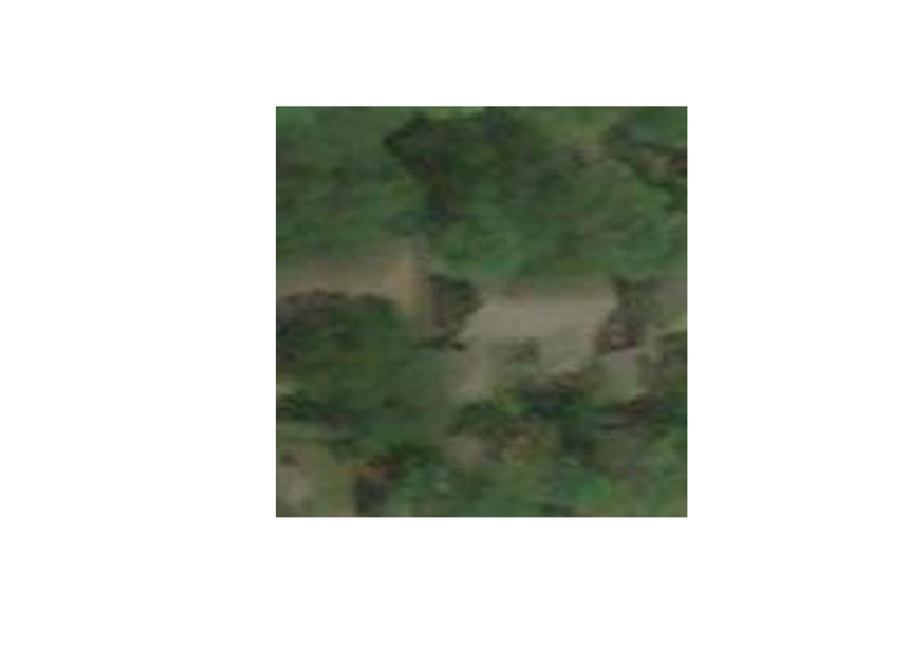

```r
plot(as.raster(img_tensor[1,,,]))
```

Instanziamo un modello da un tensore di input e una lista di tensori di output

```r
layer_outputs <- lapply(model$layers[1:8],function(layer) layer$output)
activation_model <- keras_model(inputs= model$input, outputs = layer_outputs)
```

il seguente comando restituisce una lista di arrays, un array per layer activation

```r
activations <- activation_model %>% predict(img_tensor)
```

activation del primo convolution layer per l’immagine dell’area danneggiata in input

```r
first_layer_activation <- activations[[1]]
dim(first_layer_activation)
```

```
## [1]   1 148 148  32
```

Funzione che ci permetterà di visualizzare i canali

```r
plot_channel <- function(channel){
  rotate <- function(x) t(apply(x,2,rev))
  image(rotate(channel), axes = FALSE, asp=1, col= terrain.colors(12))
}
```

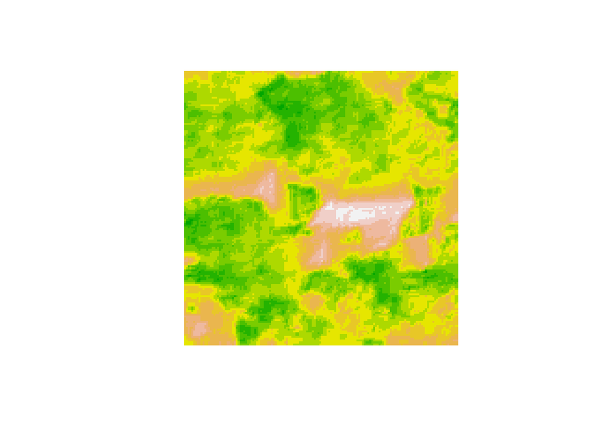

```r
plot_channel(first_layer_activation[1,,,2])
```

Secondo Canale

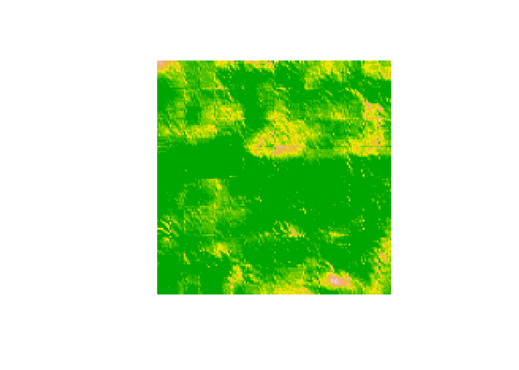

```r
plot_channel(first_layer_activation[1,,,7])
```

Settimo Canale

il ciclo for che segue serve a visualizzare ogni canale in ogni attivazione intermedia

```r
image_size <- 58
images_per_row <- 16

for (i in 1:8) {

  layer_activation <- activations[[i]]
  layer_name <- model$layers[[i]]$name

  n_features <- dim(layer_activation)[[4]]
  n_cols <- n_features %/% images_per_row

  png(paste0("damage_activations_",i,"_",layer_name, ".png"),
      width = image_size *images_per_row,
      height = image_size*n_cols)
  op <- par(mfrow=c(n_cols, images_per_row), mai= rep_len(0.02,4))

  for (col in 0:(n_cols -1)) {
    for (row in 0:(images_per_row-1)) {
      channel_image <- layer_activation[1,,,(col*images_per_row)+row+1]
      plot_channel(channel_image)

    }

  }

  par(op)
  dev.off()

}
```

Zulato Davide 876101 Denova Matteo 813101 Ferro Simone 813660